# Cell Type Distribution Score: A method to measure the overall cell type composition of samples at a single cell level

Tanya Karagiannis, Stefano Monti, Paola Sebastiani

# Introduction

The Cell Type Distribution Score is an entropy-based score to measure and assess the overall cell type composition across samples from single cell transcriptomic datasets.

Install the CTDS.score function by cloning the github repository and load the function in R.

```r
source('~/CTDS/R/distribution_score.R')
```

# Usage

We demonstrate the implementation of this method on cell type composition level data from three single cell RNA-seq datasets of aging and longevity. In this example, we apply the cell type distribution score on the normalized cell type proportions per sample and compare differences in distribution score between four age groups across the human lifespan to assess overall cell type composition in aging and extreme longevity.

Load libraries

```r
suppressMessages(c(library(dplyr),
                   library(ggplot2),
                   library(Seurat),
                   library(SingleCellExperiment),
                   library(reshape2)))
```

[output not shown]

Load integrated single cell RNA-seq datasets of PBMCs from aging and extreme longevity individuals

```r
pbmc.combined <- readRDS(file = "~/Data/pbmc.combined.rds")
```

## Creating matrix of normalized cell type proportions

Create table of normalized cell type proportions per sample (samples v. cell types) from Seurat object.

```r
ct_prop <- prop.table(table(pbmc.combined@meta.data$sample.ID, pbmc.combined@meta.data$ct.consensus), margin = 1)

head(ct_prop)
```

```
##
##        CD4 T NonCytotoxic           NK        CD8 T    BC Memory          M14
##   BU10       0.4298111281 0.2628892292 0.1153649821 0.0153139357 0.0913731496
##   BU6        0.4196610169 0.1138983051 0.1369491525 0.0291525424 0.1959322034
##   CT1        0.5878255603 0.0533010297 0.0060569352 0.0445184737 0.1387038159
##   CT2        0.2720291027 0.3623686338 0.0078819725 0.0131366209 0.1077202910
##   CT3        0.3430799220 0.2444444444 0.0101364522 0.0382066277 0.0982456140
##   CT4        0.3814270724 0.0724029381 0.0758132214 0.0453830010 0.1587093389
##
##                 mDC          M16          pDC     BC Naive       Plasma
##   BU10 0.0066360388 0.0071465033 0.0081674324 0.0076569678 0.0000000000
##   BU6  0.0162711864 0.0149152542 0.0142372881 0.0393220339 0.0000000000
##   CT1  0.0109024833 0.0299818292 0.0039370079 0.0563294973 0.0009085403
##   CT2  0.0058609539 0.0697251415 0.0036378335 0.1141875505 0.0010105093
##   CT3  0.0031189084 0.0167641326 0.0027290448 0.2077972710 0.0023391813
##   CT4  0.0081322141 0.0246589717 0.0026232949 0.1694648478 0.0041972718
##
##        T gamma delta CD4 T Cytotoxic
##   BU10  0.0546197039    0.0010209290
##   BU6   0.0196610169    0.0000000000
##   CT1   0.0021199273    0.0654149001
##   CT2   0.0115198060    0.0309215845
##   CT3   0.0062378168    0.0269005848
##   CT4   0.0225603358    0.0346274921
```

```r
# require(knitr)
# require(kableExtra)
# kable(ct_prop, caption = paste0("cell type proportions per sample"),"html") %>% kable_styling("striped") %>% scroll_box(width = "100%",height = "300px")
```

Create matrix of metadata information from Seurat object.

```r
metadat <- lapply(1:nrow(ct_prop),function(x){
  metaInfo <- unique(pbmc.combined@meta.data[pbmc.combined@meta.data[,"sample.ID"] %in% rownames(ct_prop)[x],c("age.quartiles", "sex")])
  rownames(metaInfo) <- rownames(ct_prop)[x]
  return(metaInfo)
  })

metadat <- do.call(rbind, metadat)

head(metadat)
```

```
##      age.quartiles    sex
## BU10         20-39 Female
## BU6          40-59   Male
## CT1          40-59   Male
## CT2          60-89 Female
## CT3          60-89 Female
## CT4          60-89 Female
```

Visualize cell type proportions for all samples grouped by age group.

```r
normprop <- cbind.data.frame(ct_prop, metadat)
```

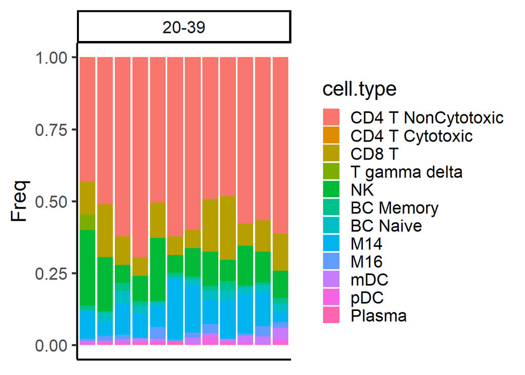

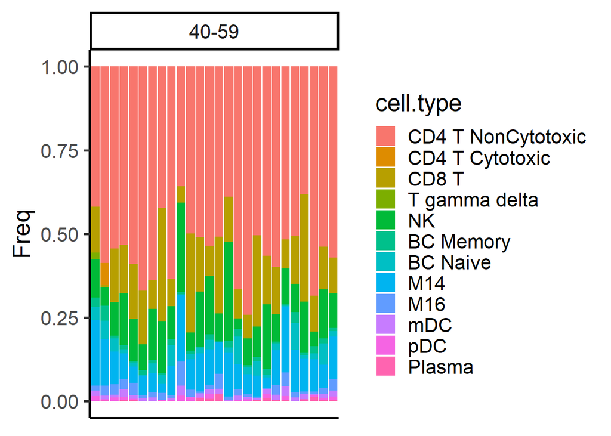

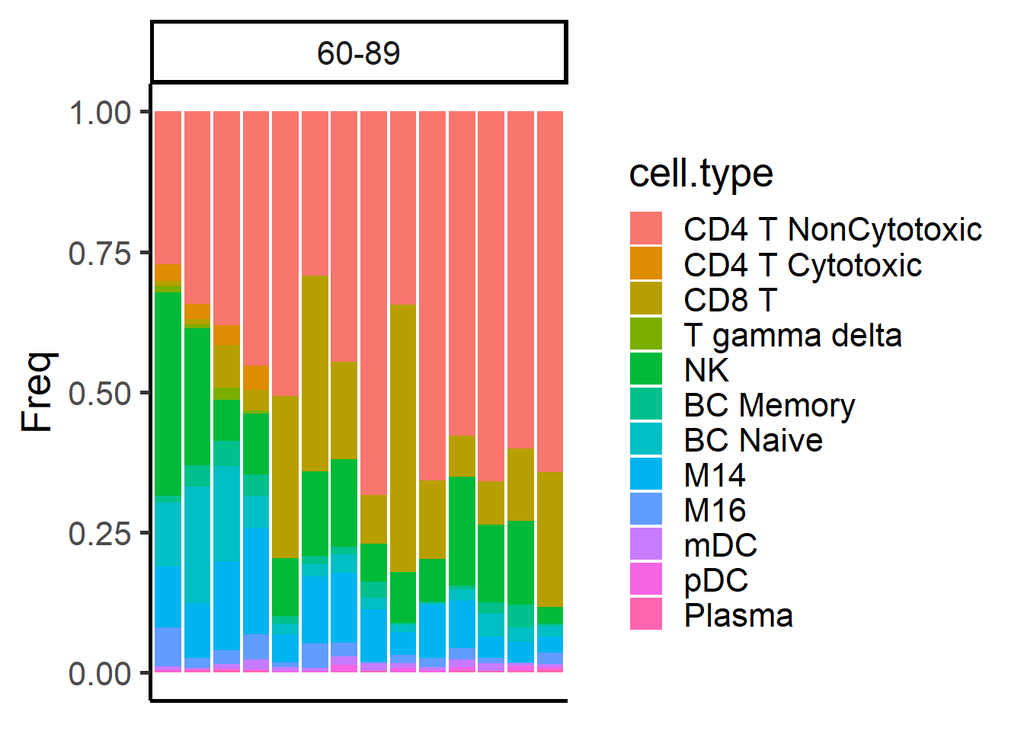

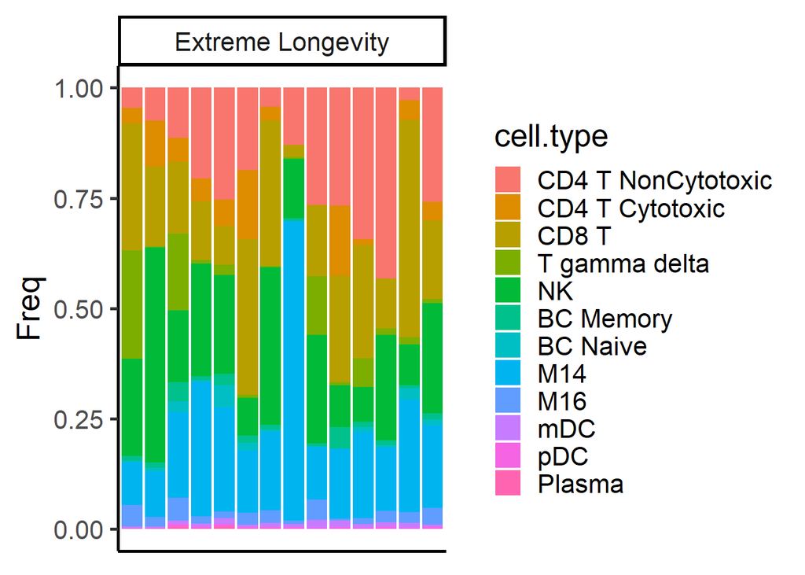

```r
colnames(normprop)[1:2] <- c("sample.ID","cell.type")

normprop$cell.type <- factor(normprop$cell.type, levels=c("CD4 T NonCytotoxic","CD4 T Cytotoxic","CD8 T","T gamma delta", "NK","BC Memory","BC Naive","M14","M16","mDC","pDC","Plasma"))

normprop$age.quartiles <- factor(normprop$age.quartiles, levels=c("20-39","40-59","60-89","Extreme Longevity"))

age.groups <- levels(normprop$age.quartiles)


for (x in 1:length(age.groups)){
  dat <- normprop %>% dplyr::filter(age.quartiles == age.groups[x])

  p4 <- ggplot(dat, aes(interaction(sample.ID, age.quartiles), Freq)) + geom_bar(aes(group = cell.type, fill = cell.type), stat="identity", position = "stack") + theme_classic(base_size = 20) + theme(axis.line=element_line()) + facet_wrap(~ age.quartiles) + theme(axis.title.x=element_blank(),
        axis.text.x=element_blank(),
        axis.ticks.x=element_blank())

 print(p4)
}
```

## Calculate cell type distribution score for each sample

### Matrix, Table Implementaion

- Run CTDS function with matrix or table of normalized cell type proportions per sample and calculate the cell type distribution score per sample.

```r
div.res <- CTDS.score(as.matrix(ct_prop), metadata = metadat)
head(div.res)
```

```
##         score age.quartiles    sex
## BU10 1.556941         20-39 Female
## BU6  1.701301         40-59   Male
## CT1  1.448109         40-59   Male
## CT2  1.706994         60-89 Female
## CT3  1.682866         60-89 Female
## CT4  1.857584         60-89 Female
```

### SingleCellExperiment Object, Seurat Object Implementation

- Run CTDS function with Seurat/SingleCellExperiment Object to calulate normalized cell type proportions per sample and calulate the cell type distribution score per sample.

```r
div.res <- CTDS.score(pbmc.combined, sample = "sample.ID", cell.type = "ct.consensus", metadata = metadat)
head(div.res)
```

```
##         score age.quartiles    sex
## BU10 1.556941         20-39 Female
## BU6  1.701301         40-59   Male
## CT1  1.448109         40-59   Male
## CT2  1.706994         60-89 Female
## CT3  1.682866         60-89 Female
## CT4  1.857584         60-89 Female
```

### Visualization and statistical tests of cell type distribution scores

Visualizations and statistical tests to compare cell type distribution scores between four age groups across the human lifespan: Younger (20-39), Middle Age (40-59), Older Age (60-89), and Extreme Longevity (100-119).

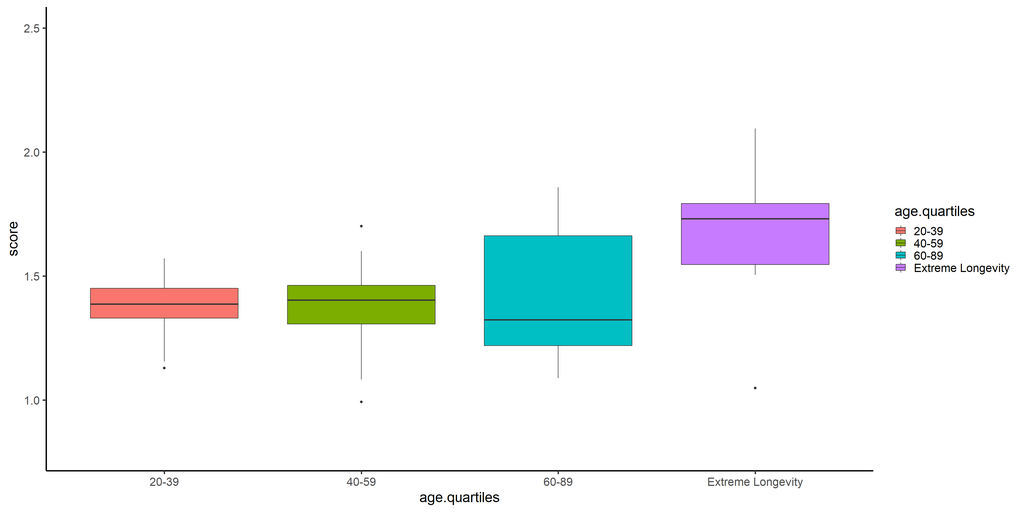

```r
require(ggplot2)
plot.ctds <- ggplot(div.res, aes(age.quartiles, score)) + geom_boxplot(aes(fill = age.quartiles)) + theme_classic(base_size = 20) + theme(axis.line=element_line()) + ylim(0.8, 2.5)

plot.ctds
```

Statistical tests - Anova and T-test of cell type distribution scores between the four age groups

```r
#Add control vs centenarian information
div.res$EL <- as.numeric(div.res$age.quartiles == "Extreme Longevity")

#histogram of cell type diversity values

#anova to test if there is a significant difference in at least one age group
lm.model <- lm(score ~ age.quartiles, data = div.res)
anova(lm.model)
```

```
## Analysis of Variance Table
##
## Response: score
##               Df  Sum Sq Mean Sq F value    Pr(>F)
## age.quartiles  3 0.97045 0.32348  8.1894 0.0001128 ***
## Residuals     62 2.44903 0.03950
## ---
## Signif. codes:  0 '***' 0.001 '**' 0.01 '*' 0.05 '.' 0.1 ' ' 1
```

```r
#pairwsie t-tests for multiple comparisons between the scores of age groups
pairwise.t.test(div.res$score, div.res$age, p.adjust.method = "BH")
```

```
##
##  Pairwise comparisons using t tests with pooled SD
##
## data:  div.res$score and div.res$age
##
##                   20-39  40-59   60-89
## 40-59             0.9323 -       -
## 60-89             0.6502 0.6250  -
## Extreme Longevity 0.0008 9.7e-05 0.0025
##
## P value adjustment method: BH
```

- Anova of cell type distribution scores between the three younger age groups

```r
#Filter out Extreme Longevity subjects
div.younger <- div.res %>% dplyr::filter(age.quartiles != "Extreme Longevity")

#anova to test if there is a significant difference in at least one age group
lm.younger <- lm(score ~ age.quartiles, data = div.younger)
anova(lm.younger)
```

```
## Analysis of Variance Table
##
## Response: score
##               Df  Sum Sq  Mean Sq F value Pr(>F)
## age.quartiles  2 0.02796 0.013980  0.4076 0.6675
## Residuals     49 1.68063 0.034299
```